# Exploring the BRFSS data

## Setup

### Load packages

```r
library(ggplot2)
library(dplyr)
```

### Load data

```r
load("brfss2013.RData")
```

## Part 1: Data

The data were collected via telephone interviews, using both landline and cell phone numbers. The survey is conducted using Random Digit Dialing which means that the numbers that are dialed are a random sample. While the phone numbers are randomly selected, they are missing individuals who do not have either a landline or cell phone number. The survey was also limited to non-institutionalized individuals. This means that the sample space for the survey is non-institutionalized Americans 18 years or older that have access to either a landline or cell phone.

Respondents of the survey are not compensated so, While the sampling is random, there is a potential bias to the data due to the reliance upon volunteer responses. This means that the survey is potentially missing individuals who either do not have the time or actively choose not to participate in the survey.

The volunteer response bias, combined with the fact that the portion of the population withouth access to a phone, could cary with it a number of confounding factors that mean that these data would NOT be able to be used to make determinations about the entire population of American adults.All said, since random assignment was not used for this survey causality can not be inferred from the data.

## Part 2: Research questions

**Research quesion 1:** Is there a difference in the proportion of individuals who wear a seatbelt based on education level?

I am curious whether or not there is a correlation between education level and seatbelt usage. If there is, that means there might be a way to target a population of people who do not wear seatbelts.

**Research quesion 2:** What is more likely to cause a heart attak, binge drinking, smoking 100 cigarettes?

**Research quesion 3:** For people that have exercised in the last 30 days, do they on average eaten more fruits or more vegetables?

This could be relevant for someone who might run a snackbar in a gym or rec center. They might want to know whether the patrons of the gym are more likely to want to eat fruit or vegetables so that they might propperly stock their stand and advertise the products that they have.

## Part 3: Exploratory data analysis

**Research quesion 1:** Is there a difference in the proportion of individuals who wear a seatbelt based on education level?

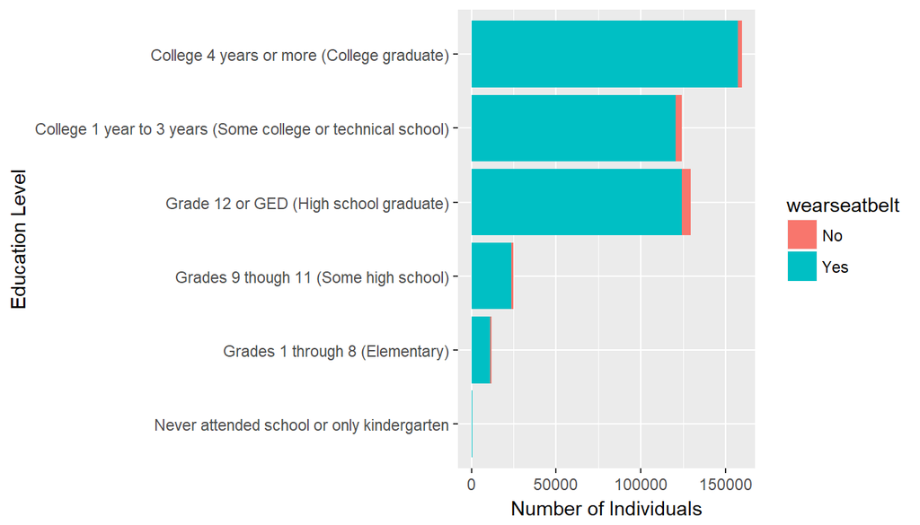

```r
brfss2013 <- brfss2013 %>% mutate(wearseatbelt = ifelse(seatbelt == 'Never', 'No', ifelse(seatbelt == 'Seldom', 'No', 'Yes')))

edu_seatbelt <- brfss2013 %>% filter(seatbelt != 'Never drive or ride in a car', !is.na(educa))

ggplot(data = edu_seatbelt, aes(x = educa, fill = wearseatbelt)) + geom_bar() + coord_flip() + ylab("Number of Individuals") + xlab("Education Level")
```

Based on the results of the bar plot it is difficult to determine is there is a difference in the proportion of individuals who wear seatbelts. I think that looking at the relative percentages would be more helpful.

```r
tt = table(edu_seatbelt$educa, edu_seatbelt$wearseatbelt)

prop.table(tt, 1)*100
```

```
##
##                                                                       No
##   Never attended school or only kindergarten                    4.770318
##   Grades 1 through 8 (Elementary)                               4.690288
##   Grades 9 though 11 (Some high school)                         4.957121
##   Grade 12 or GED (High school graduate)                        4.018472
##   College 1 year to 3 years (Some college or technical school)  2.938954
##   College 4 years or more (College graduate)                    1.534818
##
##                                                                      Yes
##   Never attended school or only kindergarten                   95.229682
##   Grades 1 through 8 (Elementary)                              95.309712
##   Grades 9 though 11 (Some high school)                        95.042879
##   Grade 12 or GED (High school graduate)                       95.981528
##   College 1 year to 3 years (Some college or technical school) 97.061046
##   College 4 years or more (College graduate)                   98.465182
```

Based on these results there may be a correlation between education level and whether or not an individual decides to wear a seatbelt. It looks as though just by taking at least one year of college that a persome is more likely to wear a seatbelt than those who do not go to college. Furthermore it looks like an even smaller precentage of individuals who complete at least four years of college don’t wear seatbelts.

With that said, the percentage of individuals across all levels of education that do not wear seatbelts is very small.

**Research quesion 2:** What is more likely to cause a heart attak, binge drinking, smoking 100 cigarettes in the last month?

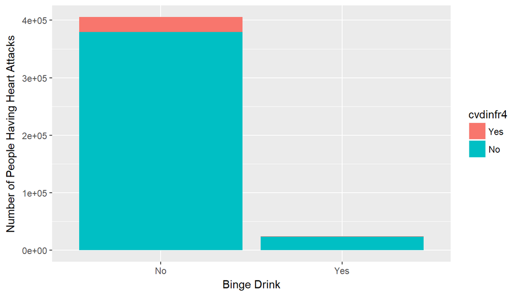

```r
brfss2013 <- brfss2013 %>% mutate(smoke_and_drink = ifelse(X_rfbing5 == 'No', 'No', ifelse(smoke100 == 'No', 'No', 'Yes')))

smoke_drink_heart <- brfss2013[c("X_rfbing5", "smoke100", "cvdinfr4", "smoke_and_drink")] %>% filter(!is.na(X_rfbing5), !is.na(smoke100), !is.na(cvdinfr4), smoke_and_drink == 'No')

ggplot(smoke_drink_heart, aes(x = X_rfbing5, fill = cvdinfr4)) + geom_bar() + ylab("Number of People Having Heart Attacks") + xlab("Binge Drink")
```

This graphic doesn’t really get to what we are looking for. There are too many people in the “No” column to see the proportion of individuals that binge drink and have had a heart attack. A relative proportion table would be more apropriate

Proportion of Binge Drinkers who have had heart attacks:

```r
t = table(smoke_drink_heart$X_rfbing5, smoke_drink_heart$cvdinfr4)
Bing_Drink_Table = prop.table(t)*100

prop.table(t,1)*100
```

```
##
##             Yes        No
##   No   6.461711 93.538289
##   Yes  1.379744 98.620256
```

The columns going across indicate whether or not someone has had a heart attack and the columns going down indicate whether or not someone binge drinks. This table would indicate that of the people that binge drink, only 1.38% have had a heart attack.

We will do the same graphic and table for individuals who smoke.

Proportion of Smokers who have had heart attacks:

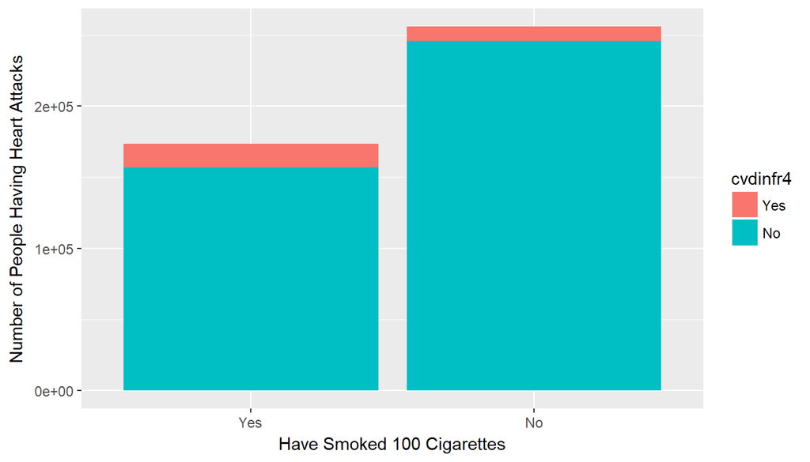

```r
ggplot(smoke_drink_heart, aes(x = smoke100, fill = cvdinfr4)) + geom_bar() + ylab("Number of People Having Heart Attacks") + xlab("Have Smoked 100 Cigarettes")
```

```r
tt = table(smoke_drink_heart$smoke100, smoke_drink_heart$cvdinfr4)
prop.table(tt,1)*100
```

```
##
##             Yes        No
##   Yes  9.566602 90.433398
##   No   3.884171 96.115829
```

Based on these data it looks like nearly 9.6% of individuals who have smoked more than 100 cigarettes have had heart attacks while just over 1.3% of individuals who have binge drank have had heart attacks. This would indicate to me that if you were going to target one activity to get people to quit, you would want to target smokers.

**Research quesion 3:** For people that have exercised in the last 30 days, do they on average eaten more fruits or more vegetables?

First we will look at histograms of fruits and vegetables consumed to determine if the data are skewed.

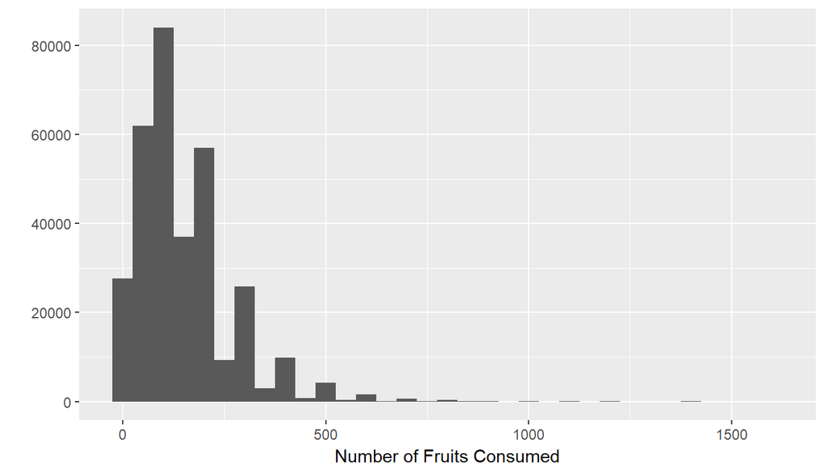

```r
exerciser_fruit <- brfss2013[c("X_totinda", "X_frutsum", "X_fruitex")] %>% filter(X_totinda == "Had physical activity or exercise", X_fruitex == "No missing values and in accepted range")

exerciser_veg <- brfss2013[c("X_totinda", "X_vegesum", "X_vegetex")] %>% filter(X_totinda == "Had physical activity or exercise", X_vegetex == 'No missing values and in accepted range')


ggplot(exerciser_fruit, aes(X_frutsum)) + geom_histogram(binwidth = 50) + xlab("Number of Fruits Consumed") + ylab("")
```

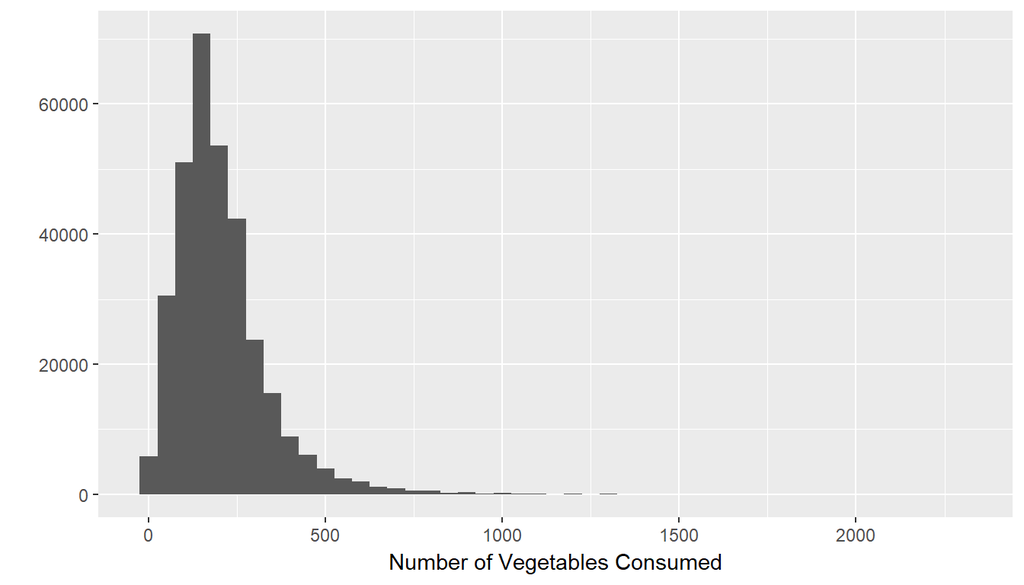

```r
ggplot(exerciser_veg, aes(X_vegesum)) + geom_histogram(binwidth = 50) + xlab("Number of Vegetables Consumed") + ylab("")
```

The results of these two histograms indicates that the data are right skewed. This means that we should use median as th emeasure of center and the IQR for the spread.

```r
summary(exerciser_fruit$X_frutsum)
```

```
##    Min. 1st Qu.  Median    Mean 3rd Qu.    Max.
##     0.0    70.0   114.0   150.5   200.0  1600.0
```

```r
summary(exerciser_veg$X_vegesum)
```

```
##    Min. 1st Qu.  Median    Mean 3rd Qu.    Max.
##     0.0   117.0   179.0   204.9   257.0  2300.0
```

After limiting to the individuals that had physical exercise and had fruit and vegetable values that were withing the accepted range, you can look at the median and IQR to compare average intake of fruits and vegetables. For qualifyihng individuals, the median intake of vegetables is higher than the median intake of fruits. In fact, the 1st Quartile of vegetable intake is higher than the median fruit intake.

What this means relative to our question is that if I were going to be opening a stand selling either fruits or vegetables, I would choose to sell vegetables based on these data.